# Assignment 2: Social Media Analysis of a Conversation in Twitter

# 1. Introduction

In this assignment we are going to retrieve some tweets which are related to a specific topic. Once we’ve got the tweets, we will perform different analysis so that we can learn things about the community tweeting them. In our case, the chosen topic is going to be [Tesla](https://www.tesla.com/es_ES/). After looking for tweets with the word “Tesla” on them, we obtained a huge amount of tweets which didn’t fulfill the requirements (tweets happened only during one day). That’s why finally the search has been set to “Tesla Autopilot”, which is the system offered by Tesla on their cars.

[figure not shown]

*Figure 1: Tesla Autopilot doing its magic.*

To do so, we are going to use the following packages:

- `rtweet`
- `igraph`
- `dplyr`
- `syuzhet`
- `wordcloud`
- `tm`
- `corrplot`

# 2. Obtaining the data

First we need to set up the Twitter API connection.

Finally, we can retrieve tweets using the `search_tweets` function. We are going to specify “Tesla autopilot” as the words which the tweet has to contain. Besides that, we are only selecting English tweets, as later on we will perform sentiment analysis on them.

Let’s check the information available for each tweet.

| status_id | created_at | user_id | screen_name | text | source | reply_to_status_id | reply_to_user_id | reply_to_screen_name | is_quote | is_retweet | favorite_count | retweet_count | hashtags | symbols | urls_url | urls_t.co | urls_expanded_url | media_url | media_t.co | media_expanded_url | media_type | ext_media_url | ext_media_t.co | ext_media_expanded_url | ext_media_type | mentions_user_id | mentions_screen_name | lang | quoted_status_id | … |
| --- | --- | --- | --- | --- | --- | --- | --- | --- | --- | --- | --- | --- | --- | --- | --- | --- | --- | --- | --- | --- | --- | --- | --- | --- | --- | --- | --- | --- | --- | --- |
| 1000709265638789126 | 2018-05-27 12:04:15 | 1573191368 | biz_business | Tesla is facing mounting pressure to drop the name 'Autopilot' https://t.co/6G67Pnft1G | IFTTT | NA | NA | NA | FALSE | FALSE | 0 | 0 |  |  |  |  |  |  |  |  |  |  |  |  | NA |  |  | en | NA | … |
| 1000709125624553472 | 2018-05-27 12:03:42 | 90621700 | ewoodphoto | RT @thejournal_ie: Driverless car speeds up before crashing into fire engine in Utah https://t.co/7v6TMysGmC | Twitter for Android | NA | NA | NA | FALSE | TRUE | 0 | 2 |  |  |  |  |  |  |  |  |  |  |  |  | NA |  |  | en | NA | … |
| 1000708775706177537 | 2018-05-27 12:02:19 | 1130902086 | therealnattycfc | Tesla's 'Autopilot' system is anything but, say safety experts https://t.co/Ikn1CoxOTB https://t.co/3wjmTtIn0q | dlvr.it | NA | NA | NA | FALSE | FALSE | 0 | 0 |  |  |  |  |  |  |  |  |  |  |  |  | NA |  |  | en | NA | … |
| 1000708602770968576 | 2018-05-27 12:01:37 | 1483718396 | LadyRed_6 | RT @SecRecon: Tesla in Autopilot mode sped up before crashing! #IoT #Tech @SecRecon https://t.co/7RGoYuealF | Twitter for iPhone | NA | NA | NA | FALSE | TRUE | 0 | 1 |  |  |  |  |  |  |  |  |  |  |  |  | NA |  |  | en | NA | … |
| 1000708223672954880 | 2018-05-27 12:00:07 | 960236671596888064 | Ed01000101 | RT @ForbesTech: Consumer groups want U.S. probe of Tesla Autopilot claims in wake of crashes: https://t.co/7tfvR4ZLLc | Buffer | NA | NA | NA | FALSE | FALSE | 0 | 0 |  |  |  |  |  |  |  |  |  |  |  |  | NA |  |  | en | NA | … |
| 1000707856822255616 | 2018-05-27 11:58:39 | 18662449 | madanabhat | RT @elonmusk: Its super messed up that a Tesla crash resulting in a broken ankle is front page news and the ~40,000 people who died in US | Twitter for iPhone | NA | NA | NA | FALSE | TRUE | 0 | 26401 |  |  |  |  |  |  |  |  |  |  |  |  | NA |  |  | en | NA | … |

And also, how many tweets and RTs we have gathered.

```r
# Total number of tweets
nrow(tesla_tweets)
```

```
[1] 11498
```

```r
# Number of original tweets
nrow(tesla_tweets[tesla_tweets$is_retweet==FALSE,])
```

```
[1] 5659
```

```r
# Number of RTs
nrow(tesla_tweets[tesla_tweets$is_retweet==TRUE,])
```

```
[1] 5839
```

Nice! Now the data is ready, we can start working with it!

# 3. Sentiment Analysis

In this first analysis, we are going to classify the tweets depending on the sentiment expressed on them. The first step is stripping down the data, so that we only work with the text of the tweet.

```r
# Array with all the tweets
tesla_texts <- tesla_tweets$text
head(tesla_texts)
```

```
[1] "Tesla is facing mounting pressure to drop the name 'Autopilot' https://t.co/6G67Pnft1G"
[2] "RT @thejournal_ie: Driverless car speeds up before crashing into fire engine in Utah https://t.co/7v6TMysGmC"
[3] "Tesla's 'Autopilot' system is anything but, say safety experts https://t.co/Ikn1CoxOTB https://t.co/3wjmTtIn0q"
[4] "RT @SecRecon: Tesla in Autopilot mode sped up before crashing! #IoT #Tech @SecRecon  https://t.co/7RGoYuealF"
[5] "RT @ForbesTech: Consumer groups want U.S. probe of Tesla Autopilot claims in wake of crashes: https://t.co/7tfvR4ZLLc"
[6] "RT @elonmusk: Its super messed up that a Tesla crash resulting in a broken ankle is front page news and the ~40,000 people who died in US"
```

As can be seen, tweets are ugly. This means that first we need to clean the data, so that only text appears on it. We should remove things such as:

- Retweets (RT tag)
- Mentions
- Links
- Emojis
- Digits
- Punctuacion and white spaces

Let’s proceed!

```r
tesla_texts <- iconv(tesla_texts,"UTF-8","latin1",sub="") # emojis, end-of-line characters
tesla_texts <- gsub("(RT|via)((?:\\b\\W*@\\w+)+)", "", tesla_texts) # retweets
tesla_texts <- gsub("@\\w+", "", tesla_texts) # mentions
tesla_texts <- gsub("[[:punct:]]", "", tesla_texts) # punctuation
tesla_texts <- gsub("[[:digit:]]", "", tesla_texts) # numbers
tesla_texts <- gsub("http\\w+", "", tesla_texts) # html links
tesla_texts <- gsub("[ \t]{2,}", "", tesla_texts) # unnecessary spaces
tesla_texts <- gsub("[\r\n]", "", tesla_texts) # next line jumps
tesla_texts <- gsub("^\\s+|\\s+$", "", tesla_texts)
# check the results
head(tesla_texts)
```

```
[1] "Tesla is facing mounting pressure to drop the name Autopilot"
[2] "Driverless car speeds up before crashing into fire engine in Utah"
[3] "Teslas Autopilot system is anything but say safety experts"
[4] "Tesla in Autopilot mode sped up before crashing IoT Tech"
[5] "Consumer groups want US probe of Tesla Autopilot claims in wake of crashes"
[6] "Its super messed up that a Tesla crash resulting in a broken ankle is front page news and thepeople who died in US"
```

Alright, so now we have plain text, which is going to be the input to our sentiment analysis tools.

```r
tesla_polarity <- get_sentiment(tesla_texts,method="bing")
```

Let’s check which are the top-10 tweets with most positive polarity *(a)*.

```r
sort(tesla_tweets$text[order(tesla_polarity, decreasing = TRUE)[0:10]])
```

```
 [1] "@elonmusk @Tesla Shout out to Elon Musk and Tesla for making my Model 3 delivery the best ever! The car is even better in every imaginable aspect. Handling is exceptional. Autopilot makes it a breeze to drive around town in Houston. The car is revolutionary! https://t.co/PbW9I30NIl"
 [2] "@FullyChargedDan @DavidHsearch @DriveElectricUK @ManMadeMoon @Tesla @ecocars1 @AutoVoltMag @InsideEVs @cleantechnica @ecarstrading @EVNewsDaily Cooler, more practical, faster, easier to drive, quieter, four whee drive, more convenient to fill up, cheaper to fill up, better warranty, will proba…
 [3] "@GreaterInandOut @elonmusk @Tesla Have never owned an S but the 3 exceeds my expectations. Autopilot is my favorite feature which would exclude some used S.  Overall the S is a bigger car, better performance - but for me the 3 has more than enough space and performance. Question is if youre wi…
 [4] "@JustinCap79 @The_BruceB Tesla seems to make it pretty clear that the driver always needs to be ready to take control while using Autopilot. It really is just a smarter adaptive cruise control (at the moment). https://t.co/oixvh3uPXe"
 [5] "@Sanjeev4Agrawal @Tesla Oh my goodness am I in love with autopilot! Traffic aware cruise control is fantastic &amp; I use it all the time, and autosteer is the most beautiful thing in gridlock traffic and on long empty roadtrip highways."
 [6] "@tslajms @elonmusk @Tesla How's autopilot? Power output seems decent enough, does the car feel fast with instant torque,  even though it's a heavy car? Surprised at how many questions you've replied to already, congratulations on a beautiful car!"
 [7] "@vuyo_10 I LOVE the Panamera, but in person they dont actually look that similar (despite this photo). And model 3 might look as good but costs less, is all electric, better performance and has way better autopilot tech. So... thanks for the compliment? @elonmusk @Tesla"
 [8] "@youyouxue @mmrusso57 @elonmusk I never had a chance to meet you You You but, Im glad you are alright as well. \n\nIm with You You on this one though. Hes obviously a huge Tesla fan and was really doing a good thing for Tesla. Its apparent that autopilot needs some work on those lane splits."
 [9] "A misnomer for @Tesla is the term Autopilot. That really represents where they want to be, not where they are. It does some cool things, but it's not even close to autonomous and I wouldn't trust my life with it. What it does provide is amazing, like Traffic-Aware Cruise Control."
[10] "and I should also add that I'm being generous here trusting the private sector to design vigilance switches, given that tesla has proven three times now that they can't be trusted to even do that\n\nhttps://t.co/f9Jy8vCtBs\nhttps://t.co/cT2sv6Nw6G\nhttps://t.co/USbFTLy81D"
```

And also the most negative ones.

```r
sort(tesla_tweets$text[order(tesla_polarity, decreasing = FALSE)[0:10]])
```

```
 [1] "$TSLA DEBT,DEBT, &amp; MORE DEBT...Forget The Autopilot Crash And Recall; Tesla's Daunting Debt Repayment Schedule Is The Real Issue via @forbes https://t.co/N3DzoWTaCS"
 [2] "@AlexRoy144 @elonmusk Also dude ignores all warnings and tentative of Tesla to dissuade him from doing the trip + been doing dumb things before with autopilot. Now Teslas fault. #Stupidity"
 [3] "@TheFlyingSkibo @bryanclark @elonmusk Sustained coverage from multiple reputable outlets on issues ranging from worker safety, quality control, major financial setbacks, misleading Autopilot claims, a crazy CEO, etc. isn't indicative of bias. It means there's some major problems at Tesla that …
 [4] "@wordsbymt @gsxr_hunter @RabbiRoss @sapinker Stop your dishonest crap. Elon never refered to the his cars' autopilot as \"self-driving.\" Then again, for the short-sellers and irrational Tesla haters of your ilk, facts have never gotten in the way your delusions and myopic self-interest."
 [5] "Consumer Reports cited the Tesla 3s poor braking performance with a stopping distance \"far worse than any contemporary car we've tested\".\n\nHow many of Tesla Autopilots crashes will end up being caused simply by Teslas being mediocre sports cars, and not by not error?"
 [6] "Getting awfully sick of Tesla crash reports showing up in every media outlet ever. All cars crash. Sometimes the Autopilot is to blame, as in the crash where the sensors failed to distinguish the semi trailer from the ski. But in cases l... #NewsPicksUSA https://t.co/HG2R7vAzw6"
 [7] "How many articles start with 'driver, who irresponsibly and illegally was not looking at the road tries to blame tesla autopilot?' If the amount on your news site is ZERO, consider having a bias maybe"
 [8] "Its like @elonmusk is trying to divert attention from chronic losses, multi-billion dollar cash burn, missed production projections, looming debt maturities, shoddy quality and an autopilot that may or may not be lethal to Tesla drivers $TSLA $TSLAQ https://t.co/JuDoL1JqpE"
 [9] "When looking at @ElonBachman's $TSLA death list, you can't help but shake your head when reading this old article.\n\nTesla says jealousy, not Autopilot safety concerns, caused breakup with Mobileye https://t.co/exBrbJGOEV"
[10] "You You Xue is bad for EV+Tesla Brand. Very bad decisions, arrogant, irresponsible! now blaming Elon + Autopilot for his failures, reckless driving and self caused car crash! https://t.co/qzEbdPD55A"
```

Ok, we can see how the results make sense. Now that we have the ranking, we are going to build a wordcloud, so we can see faster which words appear the most in both possitive and negative tweets *(b)*. As we want the wordcloud to contain only significant words, we have to remove the stopwords whitin the text. That’s going to be done using the `removeWords` function included in the `tm` package.

```r
tesla_texts <- removeWords(tesla_texts, stopwords("english")) #get rid of stopwords in english
head(tesla_texts)
```

```
[1] "Tesla  facing mounting pressure  drop  name Autopilot"
[2] "Driverless car speeds   crashing  fire engine  Utah"
[3] "Teslas Autopilot system  anything  say safety experts"
[4] "Tesla  Autopilot mode sped   crashing IoT Tech"
[5] "Consumer groups want US probe  Tesla Autopilot claims  wake  crashes"
[6] "Its super messed    Tesla crash resulting   broken ankle  front page news  thepeople  died  US"
```

Now we are going the build the *Corpus* of the three different wordclouds we will display.

```r
tesla_corpus_all <- Corpus(VectorSource(tesla_texts))
tesla_corpus_pos <- Corpus(VectorSource(tesla_texts[tesla_polarity>=0]))
tesla_corpus_neg <- Corpus(VectorSource(tesla_texts[tesla_polarity<0]))
```

It’s essential to build these *Corpus*, because this is the type accepted by function `wordcloud`, that’s going to build and display them.

```r
par(mfrow=c(1,3),mar=c(4,4,1,1))
wordcloud(tesla_corpus_all, min.freq = 5, max.words=100, random.order= FALSE, colors=brewer.pal(8,"Dark2"))
wordcloud(tesla_corpus_pos, min.freq = 5, max.words=100, random.order= FALSE, colors=brewer.pal(8,"Dark2"))
```

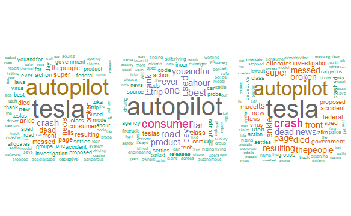

```r
wordcloud(tesla_corpus_neg, min.freq = 5, max.words=100, random.order= FALSE, colors=brewer.pal(8,"Dark2"))
```

It’s clear that these graphs could be improved, so we are going to do so. First of all we are going to remove the words “Tesla” and “Autopilot”, because it’s obvious that they are going to be the top words in the 3 wordclouds.

```r
# Clean the text again
tesla_texts_reduced <- tesla_tweets$text
tesla_texts_reduced <- iconv(tesla_texts_reduced,"UTF-8","latin1",sub="") # emojis, end-of-line characters
tesla_texts_reduced <- gsub("(RT|via)((?:\\b\\W*@\\w+)+)", "", tesla_texts_reduced) # retweets
tesla_texts_reduced <- gsub("@\\w+", "", tesla_texts_reduced) # mentions
tesla_texts_reduced <- gsub("[[:punct:]]", "", tesla_texts_reduced) # punctuation
tesla_texts_reduced <- gsub("[[:digit:]]", "", tesla_texts_reduced) # numbers
tesla_texts_reduced <- gsub("http\\w+", "", tesla_texts_reduced) # html links
tesla_texts_reduced <- gsub("[ \t]{2,}", "", tesla_texts_reduced) # unnecessary spaces
tesla_texts_reduced <- gsub("[\r\n]", "", tesla_texts_reduced) # next line jumps
tesla_texts_reduced <- gsub("^\\s+|\\s+$", "", tesla_texts_reduced)
tesla_texts_reduced <- gsub("[tT]esla", "", tesla_texts_reduced)
tesla_texts_reduced <- gsub("[aA]utopilot", "", tesla_texts_reduced)
# Obtain the polarity again
tesla_polarity_reduced <- get_sentiment(tesla_texts_reduced,method="bing")
# Remove stopwords
tesla_texts_reduced <- removeWords(tesla_texts_reduced, stopwords("english"))
# Get the corpus
tesla_corpus_all_reduced <- Corpus(VectorSource(tesla_texts_reduced))
tesla_corpus_pos_reduced <- Corpus(VectorSource(tesla_texts_reduced[tesla_polarity>=0]))
tesla_corpus_neg_reduced <- Corpus(VectorSource(tesla_texts_reduced[tesla_polarity<0]))
```

Now we can plot the new improved wordclouds.

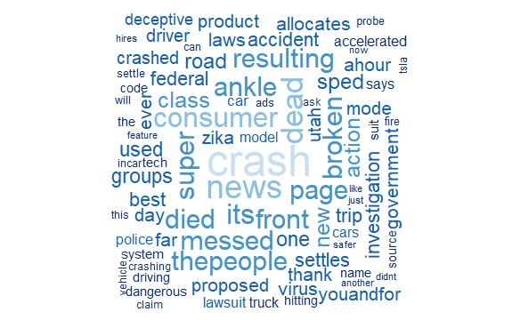

```r
colors_all = rev(colorRampPalette(brewer.pal(9,"Blues"))(32)[seq(8,32,6)])
wordcloud(tesla_corpus_all_reduced, min.freq = 5, max.words=100, random.order= FALSE, colors=colors_all, scale=c(3,.5))
```

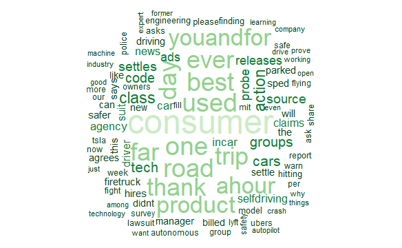

```r
colors_pos = rev(colorRampPalette(brewer.pal(9,"Greens"))(32)[seq(8,32,6)])
wordcloud(tesla_corpus_pos_reduced, min.freq = 1, max.words=100, random.order= FALSE, colors=colors_pos, scale=c(3,.5))
```

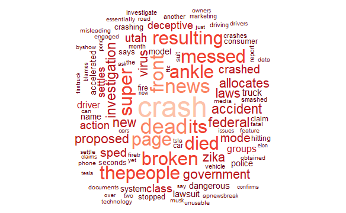

```r
colors_neg = rev(colorRampPalette(brewer.pal(9,"Reds"))(32)[seq(8,32,6)])
wordcloud(tesla_corpus_neg_reduced, min.freq = 5, max.words=100, random.order= FALSE, colors=colors_neg, scale=c(3,.5))
```

It’s visible that the most important words in the positive wordcloud are *best*, *thank* or *consumer*. On the other hand, the words with higher impact on the negative cloud are *crash* and *dead*. Same pattern repeats in the wordcloud which contains both possitive and negative tweets. Looks like, in general, people is more interested in the crashes than in the safety of the system. It’s important to know that this is a hot topic right now, as some days ago a [Tesla Model S crashed while having Autopilot on](https://abcnews.go.com/Technology/wireStory/police-report-tesla-autopilot-sped-utah-crash-55424283). That’s probably the reason why negative comments are higher in number at the moment.

# 4. Interaction between users using RTs

In this section, we are going to build a graph in which each node is an user. In that graph, a link between A and B means that A has retweeted a tweet coming from B.

Now we are going to filter to obtain only RTs and store their index in variable `rts`.

```r
# Clean the text a little bit
tesla_tweets$text <- iconv(tesla_tweets$text,"UTF-8","ASCII",sub="") # get rid of emojis, strange caracters
tesla_tweets$text <- gsub("\n","",tesla_tweets$text) # get rid of end-of-line
# Obtain only retweets
rts <- rts <- grep("^rt @[a-z0-9_]{1,15}", tolower(tesla_tweets$text), perl=T)
head(tesla_tweets$text[rts])
```

```
[1] "RT @thejournal_ie: Driverless car speeds up before crashing into fire engine in Utah https://t.co/7v6TMysGmC"
[2] "RT @SecRecon: Tesla in Autopilot mode sped up before crashing! #IoT #Tech @SecRecon  https://t.co/7RGoYuealF"
[3] "RT @ForbesTech: Consumer groups want U.S. probe of Tesla Autopilot claims in wake of crashes: https://t.co/7tfvR4ZLLc"
[4] "RT @elonmusk: Its super messed up that a Tesla crash resulting in a broken ankle is front page news and the ~40,000 people who died in US"
[5] "RT @MattLevinson: Thank you @elonmusk and @tesla for by FAR the best consumer product I have ever used. Day one is a 6 hour road trip to ca"
[6] "RT @elonmusk: Its super messed up that a Tesla crash resulting in a broken ankle is front page news and the ~40,000 people who died in US"
```

Obtain the name of the sender and the receiver of the RT.

```r
rt.sender <- gsub("^.*@([a-z0-9_]{1,15})+.*$", "\\1",tolower(tesla_tweets$screen_name[rts]), perl=T)
rt.receiver <- gsub("^rt @([a-z0-9_]{1,15}):+.*$", "\\1", tolower(tesla_tweets$text[rts]), perl=T)
```

Finally, the graph is built using the information stored in `rt.sender` and `rt.receiver`.

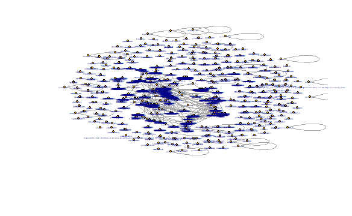

```r
# Obtain the list with the edges
edgelist <- data.frame(rt.sender,rt.receiver,stringsAsFactors=F)
# Build and plot the graph
g <- graph.data.frame(edgelist)
plot(g,vertex.size=2,edge.arrow.size=.01,asp=5/10,vertex.label.cex=0.2)
```

The graph can’t get any better than that unless we reduce the number of nodes displayed. For that reason, we are going to modify it so only the biggest component appears. This is going to be useful because we want to study the relationships between users, not the isolated users (at least not in this study).

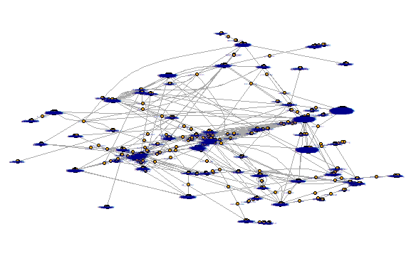

```r
par(mar=c(0,0,0,0))
cc <- clusters(g)
g0 <- delete.vertices(g,which(cc$membership!=which.max(cc$csize)))
plot(g0,vertex.size=2,edge.arrow.size=.01,asp=5/10,vertex.label.cex=0.2)
```

# 5. User influence metrics

At this point, by taking a look at the previous graph, we can guarantee that some users are much more important than others. Now, we are going to build rankings based on different metrics, which are:

- *Activity*: We are going to build a top-10 of users with most tweets including our hot words “Tesla Autopilot”. We need to take into account that not because an user tweets a lot it means that he is an influencer in the topic!
- *RTs received*: We will just count the number of RT per user. In this case, a larger number of RTs is related to the importance of the user receiving the RT. In this section, we expect users such as `@elonmusk` or `@teslamotors` to have the biggest number of RTs.
- *Centrality*: To be specific, we will obtain the PageRank centrality. This metric is going to rank each user depending on their importance, as it’s going to select a node as important if it is RT’d by other important nodes.

```r
# Activity table
activity <- data.frame(table(tolower(tesla_tweets$screen_name)))
colnames(activity) <- c("user","ntweets")
# Degree and Centrality (RT related)
degRT <- degree(g0,mode="in") #consider only incoming RTs
cenRT <- page_rank(g0)$vector
# Table mergin all the data
influenceRT <- data.frame(user=V(g0)$name,degRT,cenRT)
influence <- merge(activity,influenceRT)
# top-10 by activity
arrange(influence,desc(ntweets))[0:10,]
```

|  | user | ntweets | degRT | cenRT |
| --- | --- | --- | --- | --- |
| 1 | kirillklip | 28 | 66 | 0.0045069080 |
| 2 | blainefundlp | 23 | 2 | 0.0001926287 |
| 3 | sufiy | 21 | 0 | 0.0001002839 |
| 4 | lithiumspot | 19 | 0 | 0.0001002839 |
| 5 | zippylab | 16 | 0 | 0.0001002839 |
| 6 | librab103 | 15 | 1 | 0.0001097552 |
| 7 | ctr4autosafety | 13 | 24 | 0.0011703622 |
| 8 | crypto_news___ | 12 | 0 | 0.0001002839 |
| 9 | johnfalatjr | 12 | 0 | 0.0001002839 |
| 10 | teslaagnostic | 12 | 0 | 0.0001002839 |

```r
# top-10 by number of RTs
arrange(influence,desc(degRT))[0:10,]
```

|  | user | ntweets | degRT | cenRT |
| --- | --- | --- | --- | --- |
| 1 | elonmusk | 1 | 1446 | 0.122762564 |
| 2 | issyelliot | 1 | 836 | 0.071006867 |
| 3 | mattlevinson | 4 | 810 | 0.170155070 |
| 4 | lexfridman | 2 | 131 | 0.012281024 |
| 5 | apwestregion | 2 | 111 | 0.008880344 |
| 6 | abc | 2 | 101 | 0.008293600 |
| 7 | foxnews | 1 | 100 | 0.008234374 |
| 8 | electrekco | 3 | 92 | 0.004823233 |
| 9 | businessinsider | 7 | 79 | 0.005014936 |
| 10 | kirillklip | 28 | 66 | 0.004506908 |

```r
# top-10 by PageRank centrality
arrange(influence,desc(cenRT))[0:10,]
```

|  | user | ntweets | degRT | cenRT |
| --- | --- | --- | --- | --- |
| 1 | mattlevinson | 4 | 810 | 0.170155070 |
| 2 | elonmusk | 1 | 1446 | 0.122762564 |
| 3 | issyelliot | 1 | 836 | 0.071006867 |
| 4 | lexfridman | 2 | 131 | 0.012281024 |
| 5 | apwestregion | 2 | 111 | 0.008880344 |
| 6 | abc | 2 | 101 | 0.008293600 |
| 7 | foxnews | 1 | 100 | 0.008234374 |
| 8 | bwlogan | 1 | 21 | 0.005942785 |
| 9 | businessinsider | 7 | 79 | 0.005014936 |
| 10 | electrekco | 3 | 92 | 0.004823233 |

# 6. Correlation between polarity and influence

As the last step, we are going to study if there is any correlation between polarity and influence. One may think that, due to Twitter’s nature, negatives tweets may have bigger influence than possitive ones. Let’s finds out!

```r
# Add the polarity to each tweet in the dataset
tesla_tweets["polarity"] <- get_sentiment(tesla_texts, method="bing")
# Obtain the average polarity of each user
avg_polarity <- aggregate(tesla_tweets$polarity, by=list(tesla_tweets$screen_name), FUN=mean)
colnames(avg_polarity) <- c("user","avgPOL")
# Add it to the table
influence_final <- merge(avg_polarity,influence)
# top-10 by polarity
arrange(influence_final,desc(avgPOL))[0:10,]
```

|  | user | avgPOL | ntweets | degRT | cenRT |
| --- | --- | --- | --- | --- | --- |
| 1 | _falsemirror | 3 | 1 | 0 | 0.0001002839 |
| 2 | alexhern | 3 | 1 | 4 | 0.0003162286 |
| 3 | _allthechutney | 2 | 1 | 0 | 0.0001002839 |
| 4 | _falcon9_ | 2 | 1 | 0 | 0.0001002839 |
| 5 | _khangg | 2 | 1 | 0 | 0.0001002839 |
| 6 | _lord_commander | 2 | 1 | 0 | 0.0001002839 |
| 7 | _louisr_ | 2 | 1 | 0 | 0.0001002839 |
| 8 | _sxnk | 2 | 1 | 0 | 0.0001002839 |
| 9 | _zensoul | 2 | 1 | 0 | 0.0001002839 |
| 10 | 08040e0224f9424 | 2 | 1 | 0 | 0.0001002839 |

Now that we have obtained the average polarity for each user, let’s find out if there is any correlation.

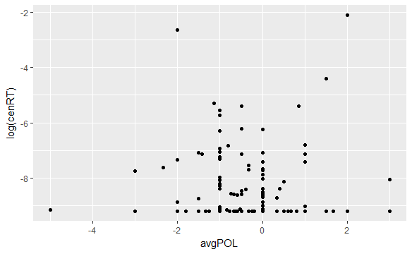

```r
#plot(influence_final$avgPOL,influence_final$cenRT, log="y", main = "Correlation Polarity-Centrality(log)", ylab = "log(Centrality)", xlab = "Average Polarity")
ggplot(data=influence_final,aes(x=avgPOL,y=log(cenRT))) + geom_point()
```

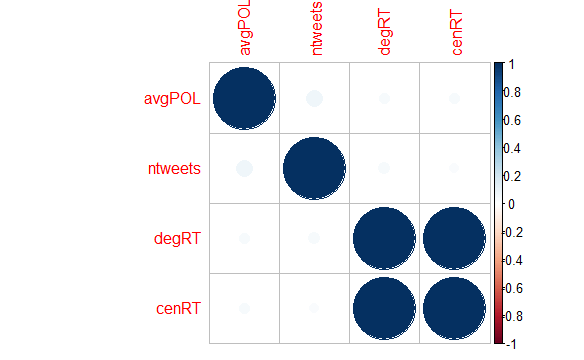

```r
M <- cor(influence_final[, 2:5])
corrplot(M, method = "circle")
```

```r
cor(influence_final$avgPOL,influence_final$cenRT)
```

```
[1] 0.03289878
```

```r
cor(influence_final$avgPOL,influence_final$ntweets)
```

```
[1] 0.06972193
```

# 7. Conclusions

We have studied different aspects of our datasets, which has helped us get an insight of the people talking about “Tesla Autopilot”. This analysis could’ve been more generalized if we had data from different months, but due to computing power and time it was not possible. In the case we were about to build an strategy to empoyer Tesla’s Autopilot image, we would have the information to target the most relevants targets.

There are still some aspects that have to be improved, such as:

- Better visualization of the RTs graphs.
- Analyze a much bigger amount of data.
- Using more attributed of the tweets to identify such as `geo_coords`, `mentions_user_id` or `favorite_count`.

Overall, I’m pretty happy with the job and, as soon as I get some free time, I will try improve it.

[This was presented as an assignment for *Network analysis and data visualization*, course taught by [Esteban Moro](https://twitter.com/estebanmoro) and part of [UC3M’s Master in Big Data Analytics](https://www.uc3m.es/ss/Satellite/Postgrado/en/Detalle/Estudio_C/1371210340413/1371219633369/Master_in_Big_Data_Analytics). Most of the code was provided by Esteban Moro, but several modifications have been added.]